# Motif Interactions

Jonathan J. Borrelli

2015

In my previous paper I showed that the 13 different three-node subgraphs differ in the probability that they will be stable (quasi sign-stability; QSS). The three subgraphs that were most stable (tritrophic chains, apparent competition, and direct competition) are also the subgraphs that are most frequently observed in empirical food webs.

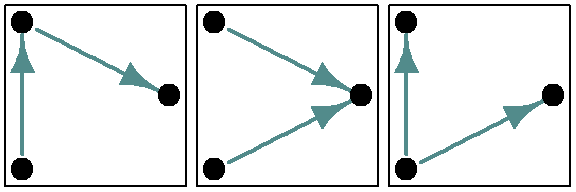

The next logical step is to try to understand how putting the three-node subgraphs together impacts their stability properties. While I suggested in the previous paper that systemic selection (via loss of unstable configurations) could lead to the observed pattern in empirical food webs I did not consider that the different subgraphs may interact to be more or less stable when combined. For example, some subgraphs that are less quasi sign-stable may be supported in food webs if they are embedded in webs that have more stable subgraphs.

To add complexity I will look at webs with 4, 5, and 10 species. How will the subgraph composition of webs impact their quasi sign-stability? Moreover, if there is an impact of composition, will it be the same across networks of different sizes? There are 199 possible ways to configure a directed network of 4 nodes. The number of ways to arrange more nodes in a directed network increases exponentially with size, so rather than use all possible configurations of 5 and 10 nodes, I will use a subsample of 1000 random networks of each size.

I would expect that when stable subgraphs come together to make a larger network, the larger network will be stable. As less stable subgraphs are included stability of the whole network will decline. As in [Prill *et al.* 2005](http://www.ncbi.nlm.nih.gov/pmc/articles/PMC1239925/) I can divide the 4, 5, and 10 node networks into 3 different stability classes. The first class is comprised of those networks that are robustly stable, with a quasi sign-stability greater than 0.8. Networks that are moderately stable (QSS between 0.3 and 0.8) are in the second stabilityclass. The third stability class is made of networks that are mostly unstable (QSS < 0.3).

# 1 Generating the networks

For the 4 node networks I simply use all 199 possible configurations, defined in Uri Alons [motif dictionary](http://wws.weizmann.ac.il/mcb/UriAlon/sites/mcb.UriAlon/files/uploads/NetworkMotifsSW/mfinder/motifdictionary.pdf).

For the 5 and 10 node networks, because it would be too time-intensive to enumerate all possible configurations. Instead I generate 1000 random samples for each. To make the 5 node networks, I created Erdos-Renyi random graphs with 5 nodes and 4 to 20 edges, with the number of edges chosen randomly (with higher probability of sampling 4-10 than 11-20). The 10 node networks were also Erdos-Renyi random graphs with a connectance chosen randomly from a beta distribution (parameters: `shape1 = 1`, `shape2 = 3`). All the networks were constrained to be connected and directed.

For each of the networks I computed the motif structure using the function `motif_counter`.

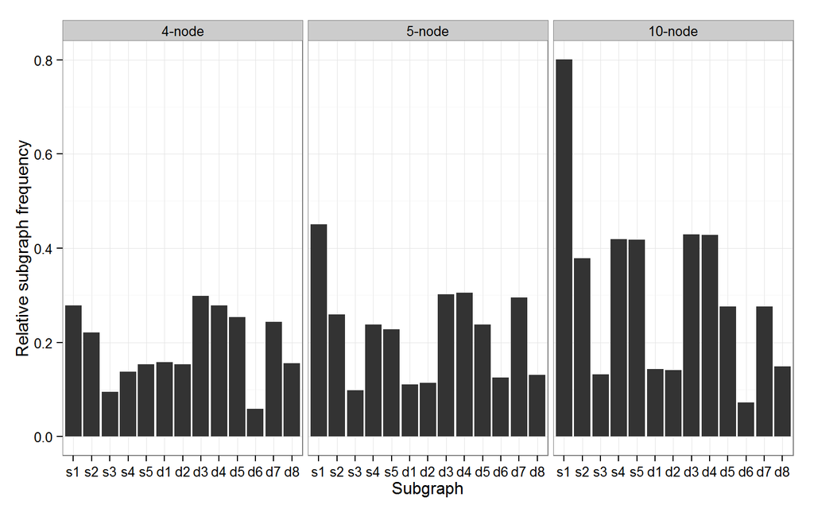

# 2 Stability of the networks

The quasi sign-stability for each 4, 5, and 10 node network was determined following the method I used in my previous two papers. The adjacency matrix of each network was converted into a sign-structured matrix.

Each sign-structured matrix was then filled with random, independently distributed values. The positive values, representing the impact of the prey on the predator, were drawn from a uniform distribution between 0 and 10. Negative values, the impact of the predator on their prey, were drawn from a uniform distribution between -1 and 0. The diagonal of the matrix, self-limitation (or density-dependence), included values drawn from a random uniform distribution between -1 and 0.

Once the matrix was filled with random values the eigenvalue with the largest real part was calculated (as max(Re($\lambda$)); `max(Re(eigen(matrix)$values))`). If this eigenvalue is negative, then the matrix is considered stable at equilibrium, while if it is positive the matrix is unstable.

This process of randomly filling the matrix and calculating the eigenvalue was repeated 1000 times for each matrix.

Quasi sign-stability of each matrix was then computed as the proportion of randomizations that were stable (negative eigenvalue).

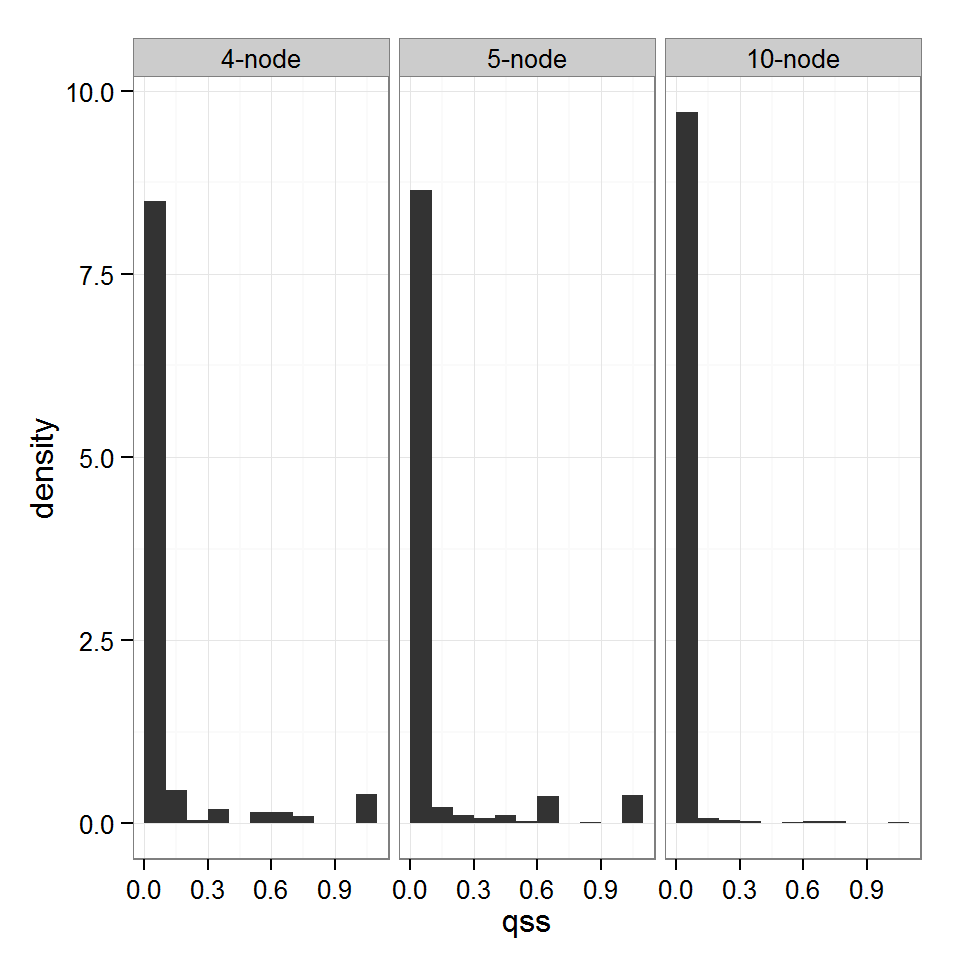

# 3 Separation into stability classes

When I split the networks of different sizes into stability classes:

- Class 1: QSS $\ge$ 0.8
- Class 2: 0.3 $\le$ QSS $<$ 0.8
- Class 3: QSS $<$ 0.3

and look at the subgraph profiles of the resulting groups, a clear pattern emerges.

In stability class one, the most stable networks, the only subgraphs present are s1 (tritrophic chain), s4 (apparent competition), and s5 (direct competition). Thus stable networks are comprised of stable subgraphs. This pattern remains the same regardless of the size of the network. The only difference between stable, and moderately stable networks is that moderately stable networks include the intra-guild predation (s2). When subgraphs other than s1, s2, s4, and s5 are included in the network stability is lost, and all networks with those subgraphs are in the third stability class (not stable).

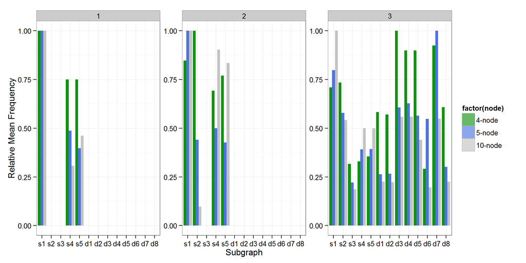

Networks composed of stable subgraphs are themselves more stable.

While the networks I have looked at here have been Erdos-Renyi random graphs, I am curious as to whether the same pattern would hold in non-random networks, such as those generated by the niche model. It would additionally be interesting to see whether changes in the assumptions I make in the distributions of the relative impacts of predators and prey on each other alter the results. Given that changing these assumptions did not alter the rank of the s1, s4, and s5 subgraphs (in order of stability), it would seem unlikely that it would change the stability classes.

What I think remains interesting here, is that the presence of unstable motifs destabilized the entire network. I would have anticipated that a network built primarily with stable building blocks could buffer some amount of negative impact of the unstable subgraphs. This must be the case, because real food webs do occasionally contain subgraphs that are not stable. In particular, for some food webs I found that the d6 subgraph was, to some extent, over-represented (although that was when excluding foodwebs in which it never appeared). One potential explanation, is that there is a difference in the strength of interactions in subgraphs that are more/less likely to be stable. If food webs were built on a core of strongly interacting stable subgraphs, it may be able to support subgraphs whose contributing links are relatively weaker.

# 4 Interaction strength combinations

I can test the idea that networks may be able to contain unstable subgraphs if the interactions that make up the unstable subgraphs are weak relative to the interactions that make up the stable subgraphs. In other words, networks composed of a core set of strongly interacting stable subgraphs may support weakly interacting subgraphs that would otherwise be unstable.

I defined a function `qssSCALED` to take in a list of networks as adjacency matrices and determine the quasi sign-stability of the network when link strength is dependent upon subgraph participation. The function first identifies which links contribute to which subgraphs. Links that contribute to the stable subgraphs (tritrophic chain, apparent competition, direct competition; s1, s4, s5) are assigned to class 1, links contributing to intraguild predation (s2) are class 2, and links contributing to all other subgraphs are assigned to class 3. These groupings were based on the resulting pattern of the above analysis on networks of different size. The function then fills the adjacency matrix with independently drawn random values from one of three uniform distributions based on the class of the link.

Class 1 link strengths are drawn from a uniform between 0 and 10 for the impact of the prey on the predator (`runif(1, 0, 10)`) and between -1 and 0 for the impact of the predator on their prey (`runif(1, -1, 0`). Link strengths for class 2 links were drawn from distributions that were 10% of class 1 links (`runif(1, 0, 1)` and `runif(1, -0.1, 0)` respectively). The strength assigned to class 3 links was again 10% of that used for class 2 links (`runif(1, 0, 0.1)` and `runif(1, -0.01, 0)` respectively).

One-thousand iterations of the random draw process were used to generate 1000 eigen values (as above I used the max(Re($\lambda$))). The quasi sign-stability of each network was then determined as the proportion of randomly filled matrices whose max(Re($\lambda$)) was negative.

I used this function on the networks that I generated above (4 nodes, 5 nodes, and 10 nodes) to determine how patterns in interaction strength as I have described change the quasi sign-stability of the networks.

```
##    user  system elapsed
## 1841.73    0.31 1844.41
```

```
##     user   system  elapsed
## 10085.67     0.81 10096.15
```

```
##     user   system  elapsed
## 16888.02     1.23 16907.91
```

What comes out of this is that the networks with scaled interaction strengths are almost always more stable than networks without scaled interaction strengths.

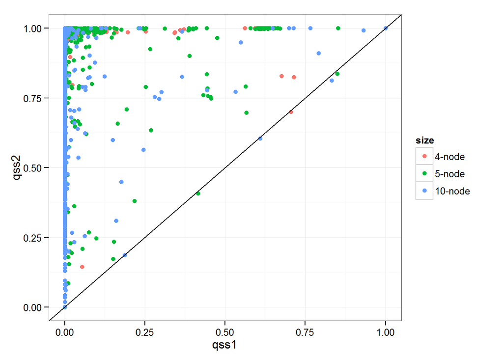

Comparing the scaled QSS to the QSS determined previously is, unfortunately using the wrong null model. I need to compare the QSS determined above to QSS calculated based on networks with the same distributions of link strengths. In other words the above result could simply be an artifact of comparing matrices with lower average interaction strength to those with higher interaction strength. As May noted, interaction strength (along with size and connectance, both of which are controlled for in this comparision) is an important factor in the stability of random matrices. Instead I can compare matrices that are filled according to the rules above, to a randomized version. The randomized version takes the paired values in the filled matrix and switches which interaction they are assigned to. Eigenvalues are then determined for the randomized matrix the same as the regular matrix.

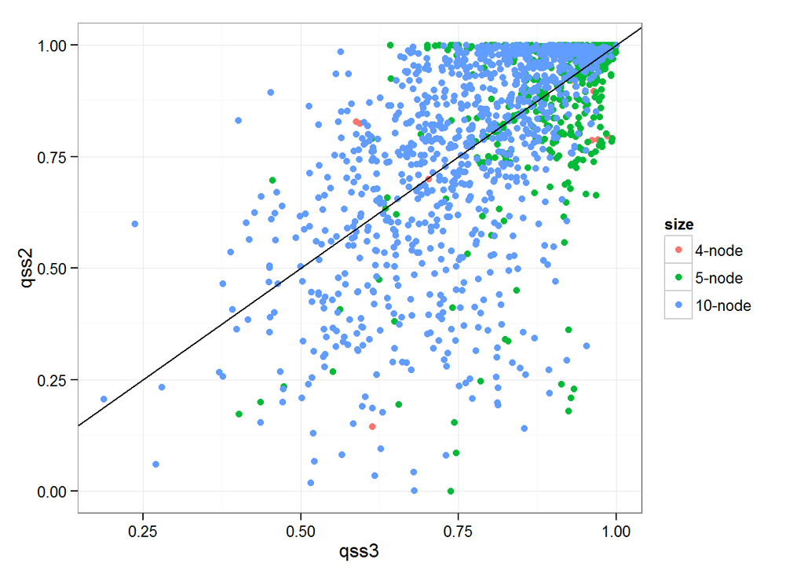